# 2022_Programming_Languages_Analysis

## Get the Data

Either use the provided .csv file or (optionally) get fresh (the freshest?) data from running an SQL query on StackExchange:

Follow this link to run the query from [StackExchange](https://data.stackexchange.com/stackoverflow/query/675441/popular-programming-languages-per-over-time-eversql-com) to get your own .csv file

```
select dateadd(month, datediff(month, 0, q.CreationDate), 0) m, TagName, count(*)
from PostTags pt
join Posts q on q.Id=pt.PostId
join Tags t on t.Id=pt.TagId
where TagName in ('java','c','c++','python','c#','javascript','assembly','php','perl','ruby','visual basic','swift','r','object-c','scratch','go','swift','delphi')
and q.CreationDate < dateadd(month, datediff(month, 0, getdate()), 0)
group by dateadd(month, datediff(month, 0, q.CreationDate), 0), TagName
order by dateadd(month, datediff(month, 0, q.CreationDate), 0)
```

## Import Statements

```python
import pandas as pd
```

## Data Exploration

**Challenge**: Read the .csv file and store it in a Pandas dataframe

```python
df = pd.read_csv('2022_QueryResults.csv', names=['DATE', 'TAG', 'POSTS'], header=0)
```

**Challenge**: Examine the first 5 rows and the last 5 rows of the of the dataframe

```python
df.head()
```

|  | DATE | TAG | POSTS |
| --- | --- | --- | --- |
| 0 | 2008-07-01 00:00:00 | c# | 3 |
| 1 | 2008-08-01 00:00:00 | assembly | 8 |
| 2 | 2008-08-01 00:00:00 | c | 83 |
| 3 | 2008-08-01 00:00:00 | c# | 506 |
| 4 | 2008-08-01 00:00:00 | c++ | 164 |

```python
df.tail()
```

|  | DATE | TAG | POSTS |
| --- | --- | --- | --- |
| 2337 | 2022-08-01 00:00:00 | php | 4278 |
| 2338 | 2022-08-01 00:00:00 | python | 23618 |
| 2339 | 2022-08-01 00:00:00 | r | 4532 |
| 2340 | 2022-08-01 00:00:00 | ruby | 490 |
| 2341 | 2022-08-01 00:00:00 | swift | 1878 |

**Challenge:** Check how many rows and how many columns there are. What are the dimensions of the dataframe?

```python
df.shape
```

```
(2342, 3)
```

**Challenge**: Count the number of entries in each column of the dataframe

```python
df.count()
```

```
DATE     2342
TAG      2342
POSTS    2342
dtype: int64
```

**Challenge**: Calculate the total number of post per language. Which Programming language has had the highest total number of posts of all time?

```python
df.groupby('TAG').sum(numeric_only=True)
# if we want the result sorted:
df.groupby('TAG').sum(numeric_only=True).sort_values(by='POSTS', ascending=False)
```

| TAG | POSTS |
| --- | --- |
| javascript | 2415257 |
| python | 2010277 |
| java | 1861157 |
| c# | 1554865 |
| php | 1443081 |
| c++ | 774157 |
| r | 461174 |
| c | 384081 |
| swift | 317442 |
| ruby | 225373 |
| perl | 67057 |
| go | 63813 |
| delphi | 49959 |
| assembly | 40995 |

**Challenge**: How many months of data exist per language? Which language had the fewest months with an entry?

```python
df.groupby('TAG').count().drop(columns='POSTS').sort_values(by='DATE', ascending=False)
```

| TAG | DATE |
| --- | --- |
| c# | 170 |
| assembly | 169 |
| c | 169 |
| c++ | 169 |
| delphi | 169 |
| java | 169 |
| javascript | 169 |
| perl | 169 |
| php | 169 |
| python | 169 |
| ruby | 169 |
| r | 167 |
| swift | 161 |
| go | 154 |

## Data Cleaning

Let's fix the date format to make it more readable. We need to use Pandas to change format from a string of "2008-07-01 00:00:00" to a datetime object with the format of "2008-07-01"

```python
df['DATE'][1]
```

```
'2008-08-01 00:00:00'
```

The square bracket notation for column names is more flexible, but with the dot notation, you get to use autocomplete, which is also nice.

```python
# If the column name has no space, we can use this notation:
df.DATE[1]
```

```
'2008-08-01 00:00:00'
```

```python
type(df.DATE[1])
```

```
str
```

```python
pd.to_datetime(df.DATE[1])
```

```
Timestamp('2008-08-01 00:00:00')
```

```python
type(pd.to_datetime(df.DATE[1]))
```

```
pandas._libs.tslibs.timestamps.Timestamp
```

```python
df.DATE = pd.to_datetime(df.DATE)
df.head()
```

|  | DATE | TAG | POSTS |
| --- | --- | --- | --- |
| 0 | 2008-07-01 | c# | 3 |
| 1 | 2008-08-01 | assembly | 8 |
| 2 | 2008-08-01 | c | 83 |
| 3 | 2008-08-01 | c# | 506 |
| 4 | 2008-08-01 | c++ | 164 |

## Data Manipulation

Sometimes you want to convert your DataFrame so that each category has its own column. For example, suppose you needed to take the table below and create a separate column for each actor, where each row is the Age of the actor:

```python
test_df = pd.DataFrame({'Age': ['Young', 'Young', 'Young', 'Young', 'Old', 'Old', 'Old'],
                        'Actor': ['Jack', 'Arnold', 'Keanu', 'Sylvester', 'Jack', 'Arnold', 'Keanu'],
                        'Power': [100, 80, 25, 50, 99, 75, 5]})
test_df
```

|  | Age | Actor | Power |
| --- | --- | --- | --- |
| 0 | Young | Jack | 100 |
| 1 | Young | Arnold | 80 |
| 2 | Young | Keanu | 25 |
| 3 | Young | Sylvester | 50 |
| 4 | Old | Jack | 99 |
| 5 | Old | Arnold | 75 |
| 6 | Old | Keanu | 5 |

The easiest way to accomplish this is by using the .pivot() method in Pandas. Try the example for yourself. The thing to understand is how to supply the correct aguments to get the desired outcome. The index are the categories for the rows. The columns are the categories for the columns. And the values are what you want in the new cells.

```python
pivoted_df = test_df.pivot(index='Age', columns='Actor', values='Power')
pivoted_df
```

| Actor Age | Arnold | Jack | Keanu | Sylvester |
| --- | --- | --- | --- | --- |
| Old | 75.0 | 99.0 | 5.0 | NaN |
| Young | 80.0 | 100.0 | 25.0 | 50.0 |

In the example above there's no value for old Sylvester. In this case, the .pivot() method will insert a NaN value.

**Challenge**: Can you pivot the df DataFrame so that each row is a date and each column is a programming language? Store the result under a variable called reshaped_df.

```python
reshaped_df = df.pivot(index='DATE', columns='TAG', values='POSTS')
```

**Challenge**: What are the dimensions of our new dataframe? How many rows and columns does it have? Print out the column names and print out the first 5 rows of the dataframe.

```python
reshaped_df.shape
```

```
(170, 14)
```

```python
reshaped_df.columns
```

```
Index(['assembly', 'c', 'c#', 'c++', 'delphi', 'go', 'java', 'javascript',
       'perl', 'php', 'python', 'r', 'ruby', 'swift'],
      dtype='object', name='TAG')
```

```python
reshaped_df.head()
```

| TAG DATE | assembly | c | c# | c++ | delphi | go | java | javascript | perl | php | python | r | ruby | swift |
| --- | --- | --- | --- | --- | --- | --- | --- | --- | --- | --- | --- | --- | --- | --- |
| 2008-07-01 | NaN | NaN | 3.0 | NaN | NaN | NaN | NaN | NaN | NaN | NaN | NaN | NaN | NaN | NaN |
| 2008-08-01 | 8.0 | 83.0 | 506.0 | 164.0 | 14.0 | NaN | 222.0 | 164.0 | 28.0 | 159.0 | 120.0 | NaN | 70.0 | NaN |
| 2008-09-01 | 28.0 | 318.0 | 1647.0 | 753.0 | 104.0 | NaN | 1133.0 | 636.0 | 130.0 | 477.0 | 537.0 | 6.0 | 287.0 | NaN |
| 2008-10-01 | 15.0 | 303.0 | 1989.0 | 809.0 | 112.0 | NaN | 1149.0 | 724.0 | 127.0 | 612.0 | 508.0 | NaN | 247.0 | NaN |
| 2008-11-01 | 17.0 | 259.0 | 1732.0 | 734.0 | 141.0 | NaN | 957.0 | 582.0 | 97.0 | 501.0 | 451.0 | 1.0 | 159.0 | NaN |

**Challenge**: Count the number of entries per programming language. Why might the number of entries be different?

```python
reshaped_df.count().to_frame(name='Nb of Entries')
# Converted into a Dataframe instead of Series to keep the nice formatting.
```

| TAG | Nb of Entries |
| --- | --- |
| assembly | 169 |
| c | 169 |
| c# | 170 |
| c++ | 169 |
| delphi | 169 |
| go | 154 |
| java | 169 |
| javascript | 169 |
| perl | 169 |
| php | 169 |
| python | 169 |
| r | 167 |
| ruby | 169 |
| swift | 161 |

```python
clean_reshaped_df = reshaped_df.fillna(value=0) # We replace all the NaN values with 0
clean_reshaped_df.head()
```

| TAG DATE | assembly | c | c# | c++ | delphi | go | java | javascript | perl | php | python | r | ruby | swift |
| --- | --- | --- | --- | --- | --- | --- | --- | --- | --- | --- | --- | --- | --- | --- |
| 2008-07-01 | 0.0 | 0.0 | 3.0 | 0.0 | 0.0 | 0.0 | 0.0 | 0.0 | 0.0 | 0.0 | 0.0 | 0.0 | 0.0 | 0.0 |
| 2008-08-01 | 8.0 | 83.0 | 506.0 | 164.0 | 14.0 | 0.0 | 222.0 | 164.0 | 28.0 | 159.0 | 120.0 | 0.0 | 70.0 | 0.0 |
| 2008-09-01 | 28.0 | 318.0 | 1647.0 | 753.0 | 104.0 | 0.0 | 1133.0 | 636.0 | 130.0 | 477.0 | 537.0 | 6.0 | 287.0 | 0.0 |
| 2008-10-01 | 15.0 | 303.0 | 1989.0 | 809.0 | 112.0 | 0.0 | 1149.0 | 724.0 | 127.0 | 612.0 | 508.0 | 0.0 | 247.0 | 0.0 |
| 2008-11-01 | 17.0 | 259.0 | 1732.0 | 734.0 | 141.0 | 0.0 | 957.0 | 582.0 | 97.0 | 501.0 | 451.0 | 1.0 | 159.0 | 0.0 |

```python
clean_reshaped_df.count().to_frame(name='Nb of Entries')
```

| TAG | Nb of Entries |
| --- | --- |
| assembly | 170 |
| c | 170 |
| c# | 170 |
| c++ | 170 |
| delphi | 170 |
| go | 170 |
| java | 170 |
| javascript | 170 |
| perl | 170 |
| php | 170 |
| python | 170 |
| r | 170 |
| ruby | 170 |
| swift | 170 |

Now, they all have the same number of entries.

We could also have done `reshaped_df.fillna(0, inplace=True)` The **inplace** argument means that we are updating reshaped_df. Without this argument we need to create a new df.

We can also check if there are any NaN values left in the entire DataFrame with this line: `reshaped_df.isna().values.any()`

```python
clean_reshaped_df.isna().values.any()
```

```
False
```

## Data Visualisaton with with Matplotlib

**Challenge**: Use the [matplotlib documentation](https://matplotlib.org/3.2.1/api/_as_gen/matplotlib.pyplot.plot.html#matplotlib.pyplot.plot) to plot a single programming language (e.g., java) on a chart.

```python
import matplotlib.pyplot as plt
```

```python
clean_reshaped_df.head()
```

| TAG DATE | assembly | c | c# | c++ | delphi | go | java | javascript | perl | php | python | r | ruby | swift |
| --- | --- | --- | --- | --- | --- | --- | --- | --- | --- | --- | --- | --- | --- | --- |
| 2008-07-01 | 0.0 | 0.0 | 3.0 | 0.0 | 0.0 | 0.0 | 0.0 | 0.0 | 0.0 | 0.0 | 0.0 | 0.0 | 0.0 | 0.0 |
| 2008-08-01 | 8.0 | 83.0 | 506.0 | 164.0 | 14.0 | 0.0 | 222.0 | 164.0 | 28.0 | 159.0 | 120.0 | 0.0 | 70.0 | 0.0 |
| 2008-09-01 | 28.0 | 318.0 | 1647.0 | 753.0 | 104.0 | 0.0 | 1133.0 | 636.0 | 130.0 | 477.0 | 537.0 | 6.0 | 287.0 | 0.0 |
| 2008-10-01 | 15.0 | 303.0 | 1989.0 | 809.0 | 112.0 | 0.0 | 1149.0 | 724.0 | 127.0 | 612.0 | 508.0 | 0.0 | 247.0 | 0.0 |
| 2008-11-01 | 17.0 | 259.0 | 1732.0 | 734.0 | 141.0 | 0.0 | 957.0 | 582.0 | 97.0 | 501.0 | 451.0 | 1.0 | 159.0 | 0.0 |

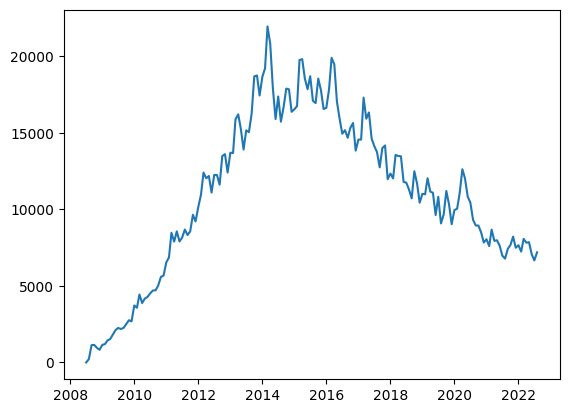

```python
plt.plot(clean_reshaped_df.index, clean_reshaped_df.java)
# N.B.: In the df, there is actually no column DATE. DATE is the index instead, which is why I have to use 'index' for the x-axis
```

To make our chart larger we can provide a width (16) and a height (10) as the figsize of the figure.

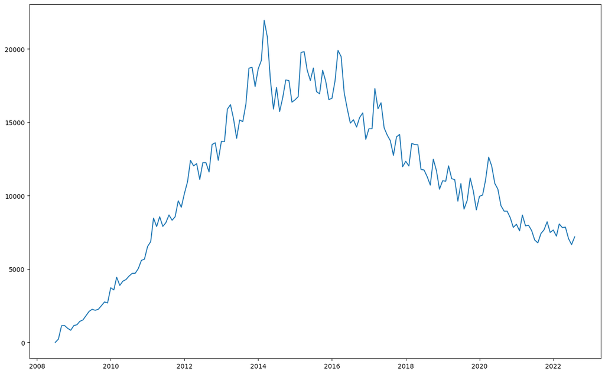

```python
plt.figure(figsize=(16,10))
plt.plot(clean_reshaped_df.index, clean_reshaped_df.java)
```

This will make our chart easier to see. But when we increase the size of the chart, we should also increase the fontsize of the ticks on our axes so that they remain easy to read:

```
plt.figure(figsize=(16,10))
plt.xticks(fontsize=14)
plt.yticks(fontsize=14)
plt.plot(clean_reshaped_df.index, clean_reshaped_df.java)
```

We can also add labels. Also, we're never going to get less than 0 posts, so let's set a lower limit of 0 for the y-axis with .ylim():

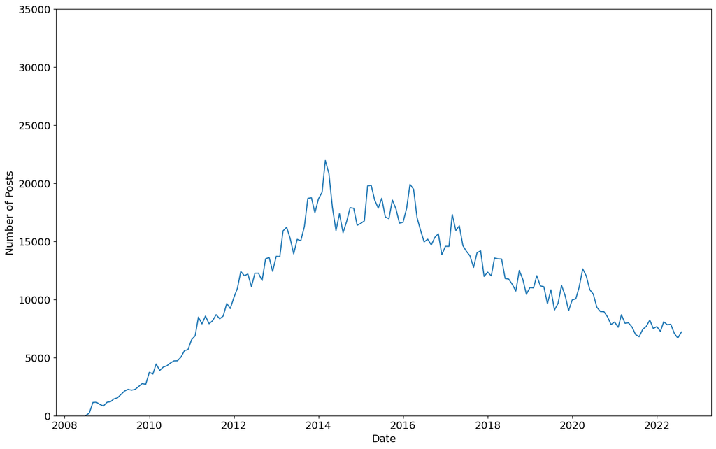

```python
plt.figure(figsize=(16,10))
plt.xticks(fontsize=14)
plt.yticks(fontsize=14)
plt.xlabel('Date', fontsize=14)
plt.ylabel('Number of Posts', fontsize=14)
plt.ylim(0, 35000)
plt.plot(clean_reshaped_df.index, clean_reshaped_df.java)
```

**Challenge**: Show two line (e.g. for Java and Python) on the same chart.

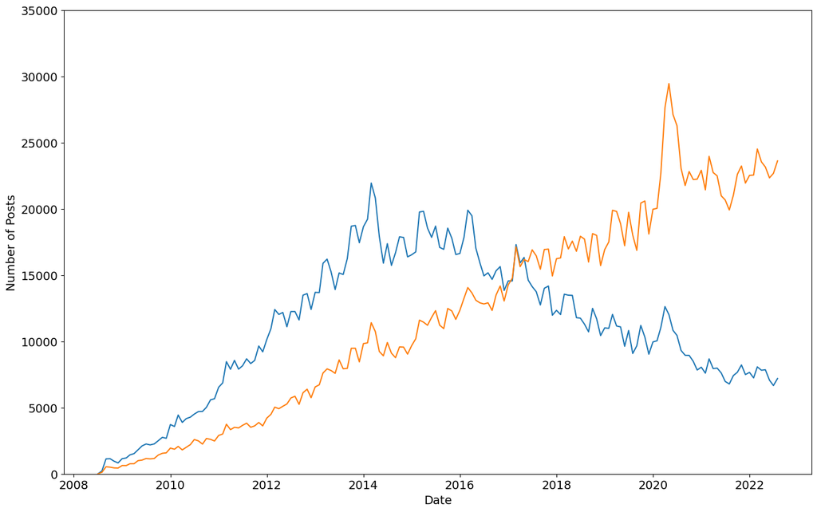

```python
plt.figure(figsize=(16,10))
plt.xticks(fontsize=14)
plt.yticks(fontsize=14)
plt.xlabel('Date', fontsize=14)
plt.ylabel('Number of Posts', fontsize=14)
plt.ylim(0, 35000)
plt.plot(clean_reshaped_df.index, clean_reshaped_df.java)
plt.plot(clean_reshaped_df.index, clean_reshaped_df.python)
```

But what if we wanted to plot all the programming languages on the same chart? We don't want to type out .plot() a million times, right? We can actually just use a for-loop:

```
for column in clean_reshaped_df.columns:
    plt.plot(clean_reshaped_df.index, clean_reshaped_df[column])
```

But wait, which language is which? It's really hard to make out without a legend that tells us which colour corresponds to each language. Let's modify the plotting code to add a label for each line based on the column name (and make the lines thicker at the same time using linewidth). Then let's add a legend to our chart:

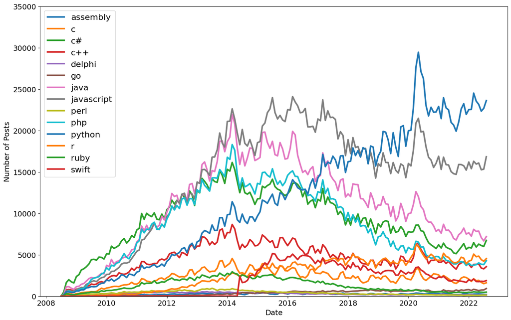

```python
plt.figure(figsize=(16,10))
plt.xticks(fontsize=14)
plt.yticks(fontsize=14)
plt.xlabel('Date', fontsize=14)
plt.ylabel('Number of Posts', fontsize=14)
plt.ylim(0, 35000)

# Plot all languages using for loop
for column in clean_reshaped_df.columns:
    plt.plot(clean_reshaped_df.index, clean_reshaped_df[column], linewidth=3, label=clean_reshaped_df[column].name)

plt.legend(fontsize=16)
```

# Smoothing out Time Series Data

Time series data can be quite noisy, with a lot of up and down spikes. To better see a trend we can plot an average of, say 6 or 12 observations. This is called the rolling mean. We calculate the average in a window of time and move it forward by one overservation. Pandas has two handy methods already built in to work this out: [rolling()](https://pandas.pydata.org/pandas-docs/stable/reference/api/pandas.DataFrame.rolling.html) and [mean()](https://pandas.pydata.org/pandas-docs/stable/reference/api/pandas.core.window.rolling.Rolling.mean.html).

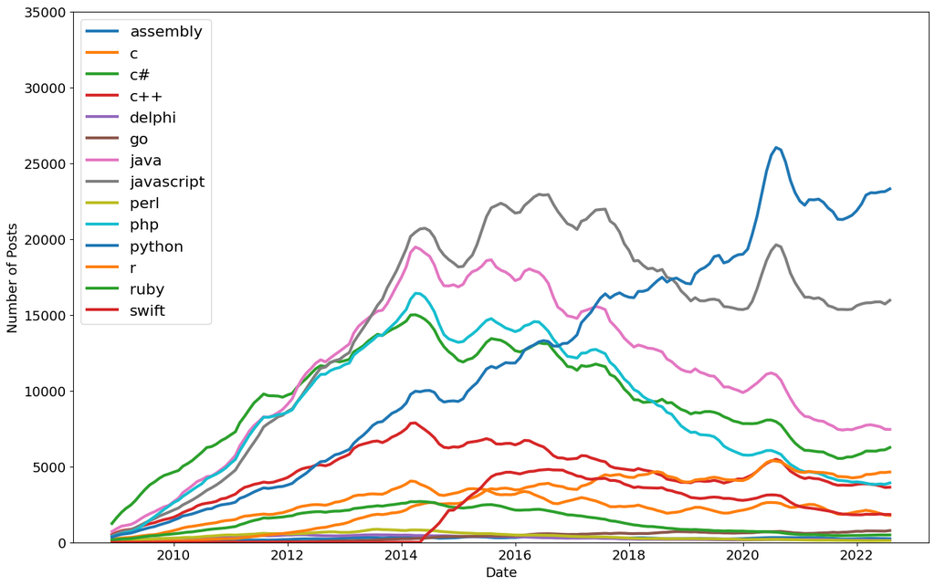

```python
# The window is number of observations that are averaged
roll_df = clean_reshaped_df.rolling(window=6).mean()

plt.figure(figsize=(16,10))
plt.xticks(fontsize=14)
plt.yticks(fontsize=14)
plt.xlabel('Date', fontsize=14)
plt.ylabel('Number of Posts', fontsize=14)
plt.ylim(0, 35000)

# plot the roll_df instead
for column in roll_df.columns:
    plt.plot(roll_df.index, roll_df[column],
             linewidth=3, label=roll_df[column].name)

plt.legend(fontsize=16)
```

Play with the window argument (use 3 or 12) and see how the chart changes!

## Learning Points & Summary

Congratulations on completing another challenging data science project! Today we've seen how to grab some raw data and create some interesting charts using Pandas and Matplotlib. We've

- used `.groupby()` to explore the number of posts and entries per programming language
- converted strings to Datetime objects with `to_datetime()` for easier plotting
- reshaped our DataFrame by converting categories to columns using `.pivot()`
- used `.count()` and `isna().values.any()` to look for NaN values in our DataFrame, which we then replaced using `.fillna()`
- created (multiple) line charts using `.plot()` with a for-loop
- styled our charts by changing the size, the labels, and the upper and lower bounds of our axis.
- added a legend to tell apart which line is which by colour
- smoothed out our time-series observations with `.rolling().mean()` and plotted them to better identify trends over time.
- used `.to_frame()` to convert a Series to a Dataframe